# Medical Devices Case Study (EDA-II)

# 1. Problem Statement

[figure not shown]

## 1.1 Background Information

Operating in the Edinburgh office of **GluMet**, a leading European medical devices company that provides technological solutions for the healthcare industry. One of the products GluMet manufactures is a **Blood-Glucose Meter**. A glucose meter is a medical device for determining the approximate concentration of glucose in the blood. It is essentially used for **Home Blood Glucose Monitoring (HBGM)** by people with diabetes. Leonard, the CEO, was continuing a long series of discussions with his partners Sebastian, COO, and Alfredo, Director of Sales, deliberating a market entry strategy for its gluco-meter devices in **Buckingham**, a town in England, and in **Louisa**.

## 1.2 Challenges at hand

As GluMet’s senior management had anticipated, entering the propsed market posed a wide variety of **challenges**.

- The lack of **brand awareness** for gluco-meter product.
- The **disjointed** customer **support services** and technical services.
- Rolling out the **updates** and **upgrade features** for the devices.

Sebastian said, “I knew it would not be easy. But I still believe we can provide value to customers.” Leonard agreed: “Considering our long-term growth goals, entering the proposed market is a necessary step for GluMet. But, in light of the challenges ahead, is it the step we should take now?”

## 1.3 Current Scenario

The management has decided to use diabetes data to double down this decision, instead of going with gut feeling. Diabetes data from the hospitals and clinics of the two places has been made available which contains patient information like age, gender, height, and weight. In addition to this, we also have anamnesis of the patients. We have diagnosis and results of the patients to see whether the patient is diabetic or not.

## 1.4 Plan of Action

Using this, the management plans to carry out **market research** and develop a statistical model which, given this information, predicts whether patient in question will buy the product or not. A successful model which is able to do this, will make the launch efficiently targeted.

## 1.5 End Result

Once the gluco-meter **awareness** and **acceptance** in these regions is matured, Glumet might have an easier time selling in these countries by leveraging its experiences and reputation. While these markets were small compared to the previous ones, they could offer a means for **GluMet to grow** in the short term.

# 2. Study Questions

- **What are the factors that will make the launch successful?**
- **How is the current market different from the previous ones?**
- **What are the strategies that we are going to opt in?**
- **What are the operational decisions need to be made?**

# 3. Product Launch Process

The product launch process starts with the following steps:

1. We are going to collect **patient information** from various hospitals and clinics.
2. Then we will carryout the **market research** on the data we have.
3. Once it’s all blended together, we will take that data and then try and come up with a **marketing analysis**.
4. Finally, we will come up with a **strategy** to enter the market.

# 4. Case Study

## 4.1 Introduction

**HbA1c** or **Glycated Hemoglobin** is most reliable test for confirming diabetes. HbA1c measurement has a central role in management of diabetes. People with diabetes need to check their glucose levels often, hence they are more likely to buy **glucometers** for regular monitoring of their HbA1c levels. Also, it would help pre-diabetic patients to take preventive measures as well

## 4.2 What is Hemoglobin A1c (HbA1c) ?

A hemoglobin A1c (HbA1c) test reflects the **average concentration of glucose in blood** over the past 2-3 months. The test measures the amount of glucose attached to hemoglobin and is reported as a percentage of total hemoglobin.

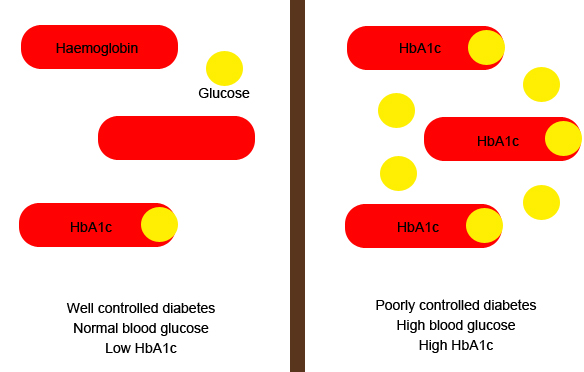

## 4.3 Why measure Hemoglobin A1c?

Having a consistently high HbA1c levels indicates either **Type 2 Diabetes** or a heightened risk for developing diabetes (**Pre-Diabetes**).

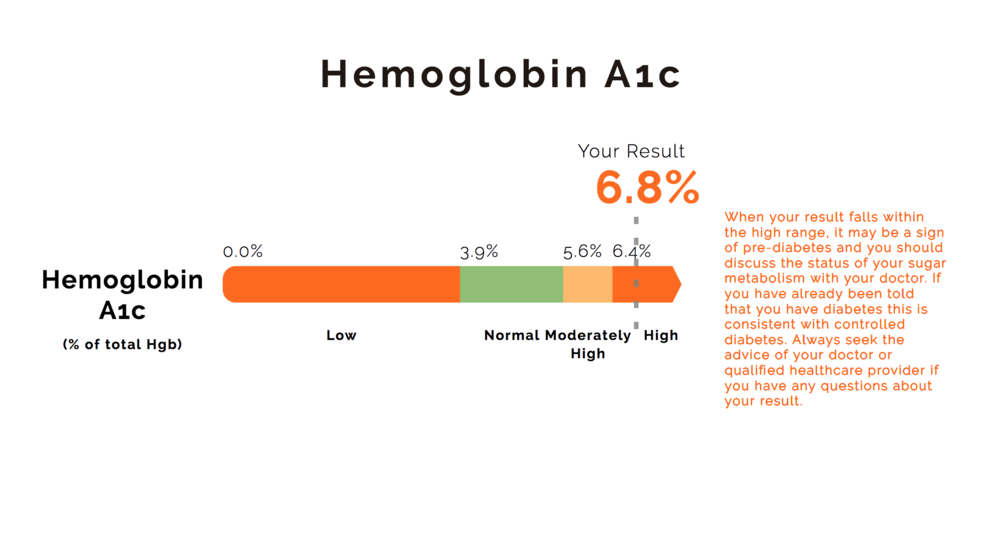

## 4.4 Why HbA1c (Glycated Hemoglobin) is most reliable test for Diabetes?

HbA1c (Glycated Hb) serves as a retrospective indicator of the average glucose concentration over the previous 6-8 weeks. HbA1c offers a potentially **easier**, **non-fasting**, and therefore more acceptable test.

## 4.5 How HbA1c is interpreted?

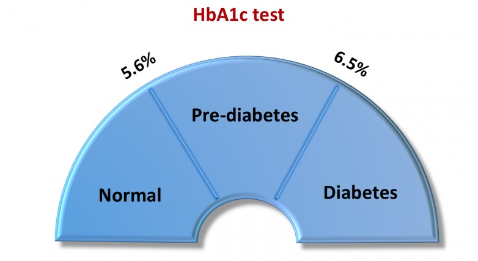

Results of HbA1c can be interpreted for diagnosis of diabetes as:

- 5.6 % and below = **Normal**
- 5.7% - 6.4% = **Pre-Diabetes**
- 6.5% and Above = **Diabetes**

# 5. Loading Packages and Libraries

Alright! lets begin our marketing research by installing some packages and loading all the libraries.

```r
# Load libraries

library(dplyr)
library(psych)
library(vtree)
library(DataExplorer)
```

# 6. Market Research Process

**Market research** is an organized effort to gather data about **target markets** or **potential customers** and then analyzing it to better understand what that group of people needs. It is a very important component of **business strategy**. The results of market research, which are usually summarized in a report, are then used to help business owners make more **informed decisions** about the company’s **strategies**, **operations**, and potential customer base.

## 6.2 Reading Data

Lets have a complete view of our dataset.

`r`r View(dataset)

Lets have a look at the head of the data.

`r`r head(dataset)

To know how the structure of the data is, we will **str** function.

`r`r str(dataset)

**glimpse** gives you a better organized structure of the data.

`r`r glimpse(dataset)

Using the **describe()** function, we can compute descriptive statistics for numerical data. The descriptive statistics help determine the distribution of numerical variables.

`r`r describe(dataset)

## 6.3 Data Profiling

Lets create a data profiling report for our dataset using the **create_report** function in **DataExplorer** package.

`r`r create_report(dataset)

## 6.4 Cleaning the Data

`r`r dataset = dataset[,-c(15,16)] print(dim(dataset))

Now, lets remove all the rows containing missing values.

`r`r row.has.na <- apply(dataset, 1, function(x){any(is.na(x))}) dataset = dataset[!row.has.na,] print(dim(dataset))

Again, lets have a look at the head of the dataset.

`r`r head(dataset)

## 6.5 Analyzing the Data

Lets use the **plot** function to do **univariate analysis** of some variables.

### 6.5.1 Which variable turns out to be significant for the analysis?

Lets begin with a very important variable **glyhb**.

`r`r plot(dataset$age)

`r`r plot(dataset$gender)

But, wait a minute, dont jump to conclusions in such an early stage of analysis. What I’ll suggest is to lookout for some metrics or statistics before you draw some conclusion.

`r`r plot(dataset$frame)

`r`r plot(dataset$location)

`r`r plot(dataset$glyhb, dataset$stab.glu)

To have a better picture, lets see who our **target customers** are in colorful visualization.

### 6.5.2 How the distribution of data is?

Lets see how the data is distributed using the **boxplots**, **histograms**, and **density plots**.

`r`r dataset_numeric = dataset[,-c(7, 9, 12, 18)]

#### 6.5.2.1 Boxplots

`r`r #Box And Whisker Plots

par(mfrow = c(3,4)) # Put four figures in a row

for(i in 2:13) { boxplot(dataset_numeric[,i], main=names(dataset_numeric)[i]) }

#### 8.6.5.2.2 Histograms

`r`r #Histograms

par(mfrow = c(3,4)) # Put four figures in a row

for (i in 2:13) { hist(dataset_numeric[,i],main=names(dataset_numeric)[i]) }

#### 6.5.2.3 Density Plots

`r`r #Density Plots

par(mfrow=c(3,4)) # Put four figures in a row

for(i in 2:13) { plot(density(dataset_numeric[,i]), main=names(dataset_numeric)[i]) }

### 6.5.3 Which age group does our target customers fall into?

Lets bin our customers into different **age groups**.

`r`r ggplot(dataset, aes(y = glyhb, x = age)) + geom_point()

- 20 - 35 yrs : **Group 1**
- 36 - 70 yrs : **Group 2**
- 71 - 100 yrs : **Group 3**

Although, the spread of our potential customers is across different age groups but, primarily we need to focus on **Diabetic** and **Pre-Diabetes** patients.

`r`r p = ggplot(dataset, aes(x = age, y = glyhb, color = diagnosis)) p+geom_jitter() + geom_boxplot()

Here we can clearly see our target customers with respect to the age groups we are looking at.

`r`r p = ggplot(dataset, aes(x = age, y = glyhb, color = result)) p+geom_point() + stat_smooth()

Again, **gruop 2** has got all our potential customers.

Let’s try to show this trend with body weight.

`r`r ggplot(dataset, aes(x=age, y=glyhb, size=weight, color=frame)) + geom_point()

To focus more on **weight** of the body, lets see how the body weights are distributed.

`r`r ggplot(dataset, aes(x = weight, y = glyhb, size=weight)) + geom_point()

Also, if we club body **weight** with body **frame**.

`r`r ggplot(dataset, aes(x = age, y = weight, size=weight, color = frame)) + geom_point()

### 6.5.4 Which gender should we focus on?

Here, lets see which gender is more prone to diabetes.

`r`r ggplot(dataset, aes(x = gender, fill = diagnosis)) + geom_bar()

`r`r ggplot(dataset, aes(x=gender, fill=frame)) + geom_bar()

`r`r vtree(dataset,location,horiz=FALSE,height=250,width=850)

Here’s what it means:

**glyhb** at the beginning means we want a summary of that variable. Next there is a separating space. The rest of the string describes the format of the output.

### 6.5.5 Which body frame should be targeted in a specific location?

`r`r ggplot(dataset , aes(x=location, fill=frame)) + geom_bar()

Running **vtree** on a single variable is equivalent to a one-way contingency table. **Valid** percentages are calculated after removing these missing values. Specifying **vp = FALSE** lets you calculate percentages without removing the missing values.

`r`r vtree(dataset,location,horiz=FALSE,height=250,width=850)

If we don’t need to see the variable names on the left-hand side, we can specify **showlevels = FALSE**

`r`r vtree(dataset,location,horiz=FALSE,height=250,width=850,showlevels=FALSE)

## 6.6 Correlation Analysis

Lets see how the variables are correlated in our dataset.

`r`r plot_correlate(dataset)

# 7. Strategy and Operations

In order to come up with **strategy** which will help us take operational decisions, what we are doing here is to transform the **result** variable which is technically a binary variable with ones and zeros. We will convert this into a factor variable with values **Positive** which is diabetic and **negative** means non-diabetic.

Before that, lets see our **diagnosis** variable which tells us about the percentage of **Diabetic**, **Non-Diabetic**, and **Pre-Diabetes** people.

Now, lets see the percentage of target customers we have based on the **result**

To prioritize our operations, lets look at the variable result with respect to **location**.

`r`r vtree(dataset, location, horiz=FALSE, height=250, width=850)